# 01 playground

```r
library(tidyverse)
library(simglm)
```

# group structure sim functions

- when a bunch of data comes from
  - same ppt
  - same school
  - same item

```r
sim_int_1grp_1pred <- function(
    seed=NULL,
    b0=0, b1=1,
    sigma2_u0=1,
    sigma=1,
    N=200, n_groups=20,
    eq=TRUE
){
  #'  Quickly sim data for a basic model y~1+x+(1|g)
  #' @param seed random seed to use
  #' @param b0 fixed intercept
  #' @param b1 fixed slope
  #' @param sigma2_u0 random intercept variance
  #' @param sigma residual sd
  #' @param N how many obs
  #' @param n_groups how many groups
  #' @param eq equality of x between groups (if true, categ x1, else zscore)

  if(!is.null(seed)){
    set.seed(seed)
  }

  g = rep(1:n_groups, e = N/n_groups)

  if(eq){
    x1 = rep(1:(N/n_groups), n_groups)
  } else {
    x1 = rnorm(N)
  }

  # intercept adjustments
  u0 = rnorm(n_groups, mean = 0, sd = sqrt(sigma2_u0))[g]

  lp = (b0 + u0) + (b1 * x1)

  y = rnorm(N, mean = lp, sd = sigma)             # continuous target
  y_bin = rbinom(N, size = 1, prob = plogis(lp))  # binary target

  data.frame(x1, g=factor(g), y, y_bin)
}

sim_int_1grp_1pred(seed = 1, N = 6, n_groups = 2, eq = T)
```

| x1 | g | y | y_bin |
| --- | --- | --- | --- |
| 1 | 1 | -0.4620824 | 0 |
| 2 | 1 | 2.9688270 | 0 |
| 3 | 1 | 2.7030540 | 1 |
| 1 | 2 | 0.3631749 | 0 |
| 2 | 2 | 2.6710724 | 0 |
| 3 | 2 | 3.9219680 | 1 |

```r
sim_intslp_1grp_1pred <- function(
    seed=NULL,
    b0=0, b1=1,
    sigma2_u0=1, sigma2_u1=1,
    rho=0,
    sigma=1,
    N=200, n_groups=20,
    eq=TRUE
){
  #'  Quickly sim data for a basic model y~1+x+(1+x|g)
  #' @param seed random seed to use
  #' @param b0 fixed intercept
  #' @param b1 fixed slope
  #' @param sigma2_u0 random intercept variance
  #' @param sigma2_u1 random slope var
  #' @param rho int-slope correl
  #' @param sigma residual SD
  #' @param eq equality of x between groups (if true, categ x1, else zscore)

  if(!is.null(seed)){
    set.seed(seed)
  }

  g = rep(1:n_groups, e = N/n_groups)

  if(eq){
    x1 = rep(1:(N/n_groups), n_groups)
  } else {
    x1 = rnorm(N)
  }

  Gcov = Matrix::nearPD(matrix(c(
    sigma2_u0,
    rho*sigma2_u0*sigma2_u1,
    rho*sigma2_u0*sigma2_u1,
    sigma2_u1
  ),nrow=2))$mat

  res = MASS::mvrnorm(n_groups, mu=c(0,0), Sigma=Gcov)
  u0  = res[,1][g]  # random intercepts
  u1  = res[,2][g]  # random slopes

  lp = (b0 + u0) + (b1 + u1) * x1

  y = rnorm(N, mean = lp, sd = sigma)             # continuous target
  y_bin = rbinom(N, size = 1, prob = plogis(lp))  # binary target

  data.frame(x1, g=factor(g), y, y_bin)
}

sim_intslp_1grp_1pred(seed = 2, N = 8, n_groups = 2, eq = T)
```

| x1 | g | y | y_bin |
| --- | --- | --- | --- |
| 1 | 1 | -1.5650116 | 0 |
| 2 | 1 | -1.2492541 | 0 |
| 3 | 1 | -0.5706342 | 0 |
| 4 | 1 | -1.4152015 | 0 |
| 1 | 2 | 4.2996988 | 0 |
| 2 | 2 | 3.3612870 | 1 |
| 3 | 2 | 5.1025740 | 1 |
| 4 | 2 | 6.8515252 | 1 |

```r
sim_int_2grp_1pred <- function(
    seed=NULL,
    b0=0, b1=1,
    sigma2_u0=1,
    sigma2_w0=1,
    sigma=1,
    N=200,
    n_groups_u=20,
    n_groups_w=10,
    eq=TRUE
){
  #' Quickly sim data for a basic crossed ranef model y~1+x+(1|g)+(1|h)
  #' @param seed random seed to use
  #' @param b0 fixed intercept
  #' @param b1 fixed slope
  #' @param sigma2_u0 random intercept variance for group g
  #' @param sigma2_w0 random intercept variance for group h
  #' @param sigma residual SD
  #' @param N how many obs (multiple of n_groups_u AND n_groups_w)
  #' @param n_groups_u how many groups of type g
  #' @param n_groups_w how many groups of type h
  #' @param eq equality of x between groups (if true, categ x1, else zscore)

  if(!is.null(seed)){
    set.seed(seed)
  }

  g = rep(1:n_groups_u, e = N/n_groups_u)
  h = rep(1:n_groups_w, e = N/n_groups_w)

  if(eq){
    x1 = rep(1:(N/(n_groups_u*n_groups_w)), (n_groups_u*n_groups_w))
  } else {
    x1 = rnorm(N)
  }

  # intercept adjustments
  u0 = rnorm(n_groups_u, mean = 0, sd = sqrt(sigma2_u0))[g]
  w0 = rnorm(n_groups_w, mean = 0, sd = sqrt(sigma2_w0))[h]

  lp = (b0 + u0 + w0) + (b1 * x1)

  y = rnorm(N, mean = lp, sd = sigma)             # continuous target
  y_bin = rbinom(N, size = 1, prob = plogis(lp))  # binary target

  data.frame(x1, g=factor(g), h=factor(h), y, y_bin)
}

sim_int_2grp_1pred(seed = 1, eq = T)
```

| x1 | g | h | y | y_bin |
| --- | --- | --- | --- | --- |
| 1 | 1 | 1 | 2.65120311 | 1 |
| 1 | 1 | 1 | 1.18973583 | 1 |
| 1 | 1 | 1 | 1.68019517 | 1 |
| 1 | 1 | 1 | 1.23871852 | 1 |
| 1 | 1 | 1 | -0.08453600 | 1 |
| 1 | 1 | 1 | 0.87752900 | 0 |
| 1 | 1 | 1 | 0.89823361 | 1 |
| 1 | 1 | 1 | 1.23321016 | 1 |
| 1 | 1 | 1 | 2.39254893 | 1 |
| 1 | 1 | 1 | 2.05569931 | 1 |

[output cut: 190 more lines]

```r
simcross <- function(seed=NULL,b0=0,b1=1,b2=1,b3=2,n_ppts=6,n_itms=4,n_obs_per=4){
  #' Quickly sim data for a big crossed ranef model
  #' y ~ 1 + a + b + c + (1 + a + b + c | ppt) + (1 + a + c | itm)
  #' @param seed random seed to use
  #' @param b0 fixed intercept
  #' @param b1 fixed slope, binary within ppts and within items
  #' @param b2 fixed slope, binary within ppts, btwn items
  #' @param n_ppts how many ppts (or groups of one kind); must div by 2
  #' @param n_itms how many itms (or groups of a diff kind); must div by 2
  #' @param n_obs_per how many obs for each ppt/itm combo; must div by 2

  if(!is.null(seed)){
    set.seed(seed)
  }

  N = n_ppts*n_itms

  # init design matrix with all combinations of ppts and items
  ds_mtx = expand.grid(ppts = 1:n_ppts, itms = 1:n_itms)

  # set up binary predictor that varies within ppts, btwn items
  # (eg, experimental condition?)
  ds_mtx$wi_ppts_btw_itms = 0
  ds_mtx$wi_ppts_btw_itms[1:(N/2)] = 1

  # set up binary predictor that varies within ppts AND within items
  # (eg, sentence version?)
  ds_mtx$wi_itms_wi_ppts = c(
    rep(rep(0:1,e=(n_ppts)/2), n_itms/2),
    rep(rep(1:0,e=(n_ppts/2)), n_itms/2)
  )

  # if >1 obs per ppt/item combo, set up num predictor
  # which varies within ppts AND within items
  ds_mtx$x = list(1:n_obs_per)
  ds_mtx = tidyr::unnest(ds_mtx,x)
  # this new pred can map to another wi/wi binary categ pred if desired
  ds_mtx$xcat = ifelse(ds_mtx$x > (n_obs_per/2), "b", "a")

  # define by-ppt int + slope vcov mtx (assume no correls)
  # slopes that need adjusted:
  # - wi_itms_wi_ppts – b1
  # - wi_ppts_btw_itms – b2
  # - x or xcat – b3
  n_by_ppt_params <- 4
  ppts_vcov <- matrix(0, nrow = n_by_ppt_params, ncol = n_by_ppt_params)
  diag(ppts_vcov) <- 1
  ppts_vcov <- Matrix::nearPD(ppts_vcov)$mat

  # sample by-ppt adjustments and store as vectors, ready to add on
  ppts_res <- MASS::mvrnorm(n_ppts, mu=rep(0, n_by_ppt_params), Sigma=ppts_vcov)
  ppts_int <- ppts_res[,1][ds_mtx$ppts]
  ppts_slp_b1 <- ppts_res[,2][ds_mtx$ppts]
  ppts_slp_b2 <- ppts_res[,3][ds_mtx$ppts]
  ppts_slp_b3 <- ppts_res[,4][ds_mtx$ppts]


  # define by-item int + slope vcov mtx (assume no correls)
  # slopes that need adjusted:
  # - wi_itms_wi_ppts – b1
  # - x or xcat – b3
  n_by_itm_params <- 3
  itms_vcov <- matrix(0, nrow = n_by_itm_params, ncol = n_by_itm_params)
  diag(itms_vcov) <- 1
  itms_vcov <- Matrix::nearPD(itms_vcov)$mat

  # sample by-item adjustments and store as vectors, ready to add on
  itms_res = MASS::mvrnorm(n_itms, mu=rep(0, n_by_itm_params), Sigma=itms_vcov)
  itms_int <- itms_res[,1][ds_mtx$itms]
  itms_slp_b1 <- itms_res[,2][ds_mtx$itms]
  itms_slp_b3 <- itms_res[,3][ds_mtx$itms]

  lp = (b0 + ppts_int + itms_int) +
    (b1 + ppts_slp_b1 + itms_slp_b1) * ds_mtx$wi_itms_wi_ppts +
    (b2 + ppts_slp_b2) * ds_mtx$wi_ppts_btw_itms +
    (b3 + ppts_slp_b3 + itms_slp_b3) * ds_mtx$x

  y = rnorm(
    N*n_obs_per,
    mean = lp,
    sd = 1
  )

  data.frame(ds_mtx, y)
}

simcross(n_obs_per = 2)
```

| ppts | itms | wi_ppts_btw_itms | wi_itms_wi_ppts | x | xcat | y |
| --- | --- | --- | --- | --- | --- | --- |
| 1 | 1 | 1 | 0 | 1 | a | 6.04345681 |
| 1 | 1 | 1 | 0 | 2 | b | 9.18385939 |
| 2 | 1 | 1 | 0 | 1 | a | 3.69259717 |
| 2 | 1 | 1 | 0 | 2 | b | 4.91065813 |
| 3 | 1 | 1 | 0 | 1 | a | 4.30773467 |
| 3 | 1 | 1 | 0 | 2 | b | 8.18481208 |
| 4 | 1 | 1 | 1 | 1 | a | 2.30351531 |
| 4 | 1 | 1 | 1 | 2 | b | 8.00008222 |
| 5 | 1 | 1 | 1 | 1 | a | 3.55706652 |
| 5 | 1 | 1 | 1 | 2 | b | 7.96003027 |

[output cut: 38 more lines]

^ if want other btwn effects, then can just filter some combinations out!

```r
n_highergroup <- 10
N <- 200

df <- do.call(rbind,
  lapply(rnorm(n_highergroup), \(x) sim_intslp_1grp_1pred(b0=x, N = N))
)
df$highergroup = rep(1:n_highergroup,e=N)

lme4::lmer(y~1+x1+(1|highergroup)+(1+x1|highergroup:g),df)
```

```
Linear mixed model fit by REML ['lmerMod']
Formula: y ~ 1 + x1 + (1 | highergroup) + (1 + x1 | highergroup:g)
   Data: df
REML criterion at convergence: 7186.198
Random effects:
 Groups        Name        Std.Dev. Corr
 highergroup:g (Intercept) 1.098
               x1          1.048    -0.07
 highergroup   (Intercept) 1.235
 Residual                  1.004
Number of obs: 2000, groups:  highergroup:g, 200; highergroup, 10
Fixed Effects:
(Intercept)           x1
     0.0831       0.9834
```

code from Jo for sim between data design matrix:

```r
# how many participants am i getting, and how do they vary?
ppts = 1:6
# observed btween ppt predictor
btw_ppt = rbinom(6,1,.5)

# assuming everybody does the same expt, this can be seen as
# "for a given ppt, what do they see?":
items = 1:4
btw_items = rep(0:1,e=max(items)/2)

# all my ppts:
allp = data.frame(ppts,btw_ppt)
# nested df for each ppts data:
allp$pdat = list(data.frame(items,btw_items))

# unnest:
tidyr::unnest(allp, pdat)
```

| ppts | btw_ppt | items | btw_items |
| --- | --- | --- | --- |
| 1 | 1 | 1 | 0 |
| 1 | 1 | 2 | 0 |
| 1 | 1 | 3 | 1 |
| 1 | 1 | 4 | 1 |
| 2 | 1 | 1 | 0 |
| 2 | 1 | 2 | 0 |
| 2 | 1 | 3 | 1 |
| 2 | 1 | 4 | 1 |
| 3 | 1 | 1 | 0 |
| 3 | 1 | 2 | 0 |

[output cut: 14 more lines]

# simdat for lec, labs

## main running example for lec 2

latin square, condition fully crossed w ppts and w items

The story: masked priming, primed with a related word vs. when primed with a distractor

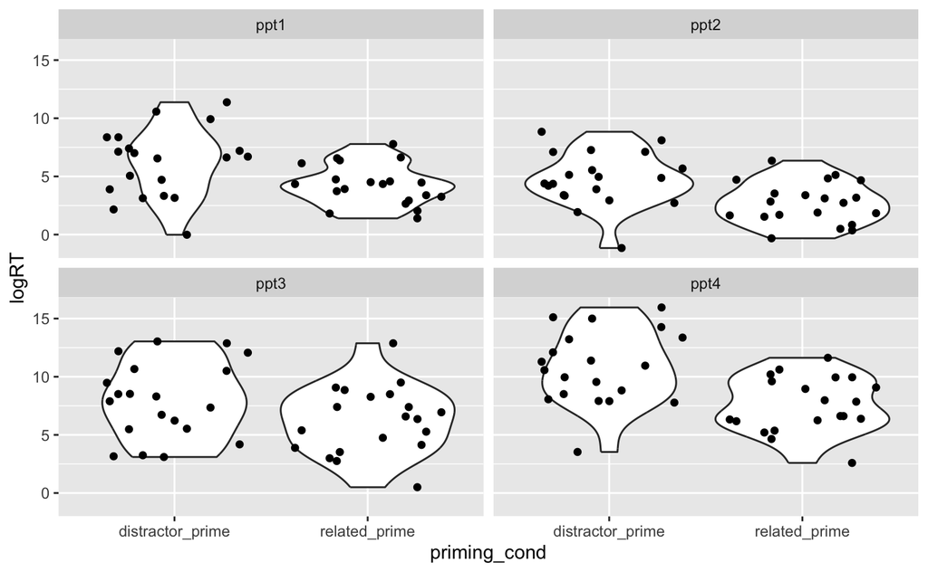

```r
n_ppts  <- 4
n_items <- 20

dat <- simcross(
  seed=1,
  b0=2,
  b1=1,  # wi_itms_wi_ppts
  b2=1,  # wi_ppts_btw_itms
  b3=2,  # x or xcat
  n_ppts=n_ppts, n_itms=n_items,
  n_obs_per=2
) |>
  select(ppts, itms, xcat, y) |>
  rename(
    ppt_id = ppts,
    item_id = itms,
    priming_cond = xcat,
    logRT = y
  ) |>
  mutate(
    priming_cond = ifelse(priming_cond == 'a', 'related_prime', 'distractor_prime'),
    ppt_id = paste0('ppt', ppt_id),
    item_id = paste0('item', item_id),
  )

dat |>
  ggplot(aes(x = priming_cond, y = logRT)) +
  geom_violin() +
  geom_jitter () +
  facet_wrap(~ ppt_id)
```

Identify grouping structure:

- we are looking only at categorical variables
- we want to see: what categorical variables have values that are associated with more than one data point?

|  | ppt_id | item_id | priming_cond | logRT |
| --- | --- | --- | --- | --- |
| 1 | ppt1 | item1 | related_prime | 3.255110 |
| 2 | ppt1 | item1 | distractor_prime | 5.056863 |
| 3 | ppt2 | item1 | related_prime | 1.839405 |
| 4 | ppt2 | item1 | distractor_prime | 3.342995 |
| 5 | ppt3 | item1 | related_prime | 6.942142 |
| 6 | ppt3 | item1 | distractor_prime | 8.523813 |

what cat vars do we have? (not including the outcome, if it’s binary) - ppt_id - item_id - priming_cond

we’ll go through each of these.

assuming data is set up for analysis using lm, with one column per variable and one row per observation, then we should just be able to count how many times each value shows up

| ppt_id | n |
| --- | --- |
| ppt1 | 40 |
| ppt2 | 40 |
| ppt3 | 40 |
| ppt4 | 40 |

can sense check by visually inspecting df. “ppt1” shows up with a bunch of different logRTs.

| item_id | n |
| --- | --- |
| item1 | 8 |
| item10 | 8 |
| item11 | 8 |
| item12 | 8 |
| item13 | 8 |
| item14 | 8 |
| item15 | 8 |
| item16 | 8 |
| item17 | 8 |
| item18 | 8 |

[output cut: 10 more lines]

each item also appears multiple times.

| priming_cond | n |
| --- | --- |
| distractor_prime | 80 |
| related_prime | 80 |

and each priming condition shows up multiple times.

So we have three groups that each contribute multiple data points:

- `ppt_id`
- `item_id`
- `priming_cond`

how do these groups relate to one another?

| ppt_id | item_id | priming_cond | n |
| --- | --- | --- | --- |
| ppt1 | item1 | distractor_prime | 1 |
| ppt1 | item1 | related_prime | 1 |
| ppt1 | item10 | distractor_prime | 1 |
| ppt1 | item10 | related_prime | 1 |
| ppt1 | item11 | distractor_prime | 1 |
| ppt1 | item11 | related_prime | 1 |
| ppt1 | item12 | distractor_prime | 1 |
| ppt1 | item12 | related_prime | 1 |
| ppt1 | item13 | distractor_prime | 1 |
| ppt1 | item13 | related_prime | 1 |

[output cut: 150 more lines]

each ppt sees each item twice, once in the distractor prime condition and once in the related prime condition.

## week 1 examples

### lifesat ~ treatment + day + (1 + day | ppt)

lifesat: continuous, measured after practicing each method daily for a week treatment: journal, meditation (btwn) day

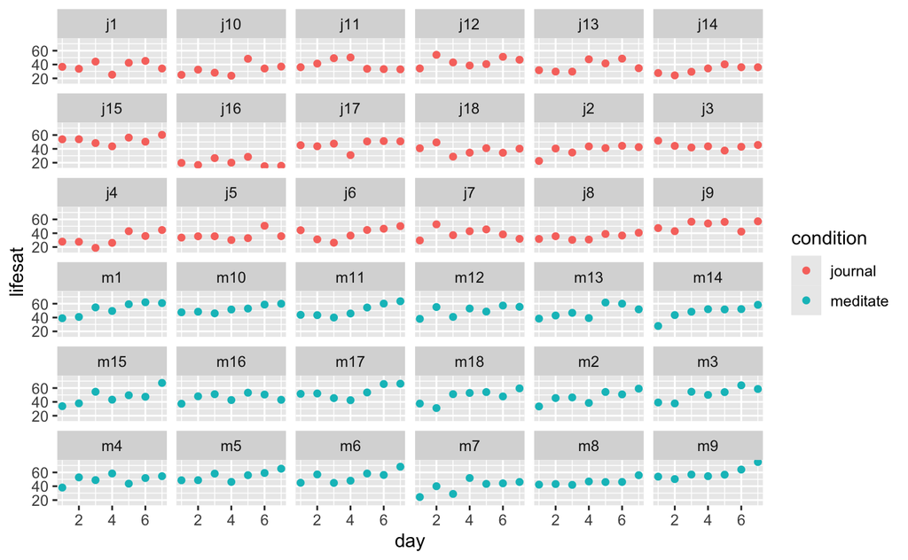

```r
half_ppts <- 18
journal <- sim_int_1grp_1pred(seed=2, b0 = 1, b1=.1, N = half_ppts*7, n_groups = half_ppts) |>
  mutate(
    condition = 'journal',
    ppt_id = paste0('j', g)
  ) |>
  select(-y_bin, -g)
meditate <- sim_int_1grp_1pred(seed=4, b0 = 1, b1=.5, N = half_ppts*7, n_groups = half_ppts) |>
  mutate(
    condition = 'meditate',
    ppt_id = paste0('m', g)
  ) |>
  select(-y_bin, -g)

lifesat_dat <- bind_rows(journal, meditate) |>
  rename(day = x1) |>
  mutate(lifesat = datawizard::rescale(y, to = c(15, 75))) |>
  select(-y)

lifesat_dat |>
  ggplot(aes(x = day, y = lifesat, colour = condition)) +
  geom_point() +
  facet_wrap(~ ppt_id)
```

what categ vars in dataset?

- condition
- ppt_id

what categ vars not an outcome or a predictor?

- ppt_id

what levels?

```r
lifesat_dat$ppt_id
```

```
  [1] "j1"  "j1"  "j1"  "j1"  "j1"  "j1"  "j1"  "j2"  "j2"  "j2"  "j2"  "j2"  "j2"  "j2"  "j3"  "j3"  "j3"  "j3"
 [19] "j3"  "j3"  "j3"  "j4"  "j4"  "j4"  "j4"  "j4"  "j4"  "j4"  "j5"  "j5"  "j5"  "j5"  "j5"  "j5"  "j5"  "j6"
 [37] "j6"  "j6"  "j6"  "j6"  "j6"  "j6"  "j7"  "j7"  "j7"  "j7"  "j7"  "j7"  "j7"  "j8"  "j8"  "j8"  "j8"  "j8"
 [55] "j8"  "j8"  "j9"  "j9"  "j9"  "j9"  "j9"  "j9"  "j9"  "j10" "j10" "j10" "j10" "j10" "j10" "j10" "j11" "j11"
 [73] "j11" "j11" "j11" "j11" "j11" "j12" "j12" "j12" "j12" "j12" "j12" "j12" "j13" "j13" "j13" "j13" "j13" "j13"
 [91] "j13" "j14" "j14" "j14" "j14" "j14" "j14" "j14" "j15" "j15" "j15" "j15" "j15" "j15" "j15" "j16" "j16" "j16"
[109] "j16" "j16" "j16" "j16" "j17" "j17" "j17" "j17" "j17" "j17" "j17" "j18" "j18" "j18" "j18" "j18" "j18" "j18"
[127] "m1"  "m1"  "m1"  "m1"  "m1"  "m1"  "m1"  "m2"  "m2"  "m2"  "m2"  "m2"  "m2"  "m2"  "m3"  "m3"  "m3"  "m3"
[145] "m3"  "m3"  "m3"  "m4"  "m4"  "m4"  "m4"  "m4"  "m4"  "m4"  "m5"  "m5"  "m5"  "m5"  "m5"  "m5"  "m5"  "m6"
[163] "m6"  "m6"  "m6"  "m6"  "m6"  "m6"  "m7"  "m7"  "m7"  "m7"  "m7"  "m7"  "m7"  "m8"  "m8"  "m8"  "m8"  "m8"
[181] "m8"  "m8"  "m9"  "m9"  "m9"  "m9"  "m9"  "m9"  "m9"  "m10" "m10" "m10" "m10" "m10" "m10" "m10" "m11" "m11"
[199] "m11" "m11" "m11" "m11" "m11" "m12" "m12" "m12" "m12" "m12" "m12" "m12" "m13" "m13" "m13" "m13" "m13" "m13"
[217] "m13" "m14" "m14" "m14" "m14" "m14" "m14" "m14" "m15" "m15" "m15" "m15" "m15" "m15" "m15" "m16" "m16" "m16"
[235] "m16" "m16" "m16" "m16" "m17" "m17" "m17" "m17" "m17" "m17" "m17" "m18" "m18" "m18" "m18" "m18" "m18" "m18"
```

is each level associated with more than one data point?

| day | condition | ppt_id | lifesat |
| --- | --- | --- | --- |
| 1 | journal | j1 | 36.64924 |
| 2 | journal | j1 | 33.79963 |
| 3 | journal | j1 | 44.22736 |
| 4 | journal | j1 | 25.30714 |
| 5 | journal | j1 | 42.44144 |
| 6 | journal | j1 | 45.19884 |
| 7 | journal | j1 | 34.23056 |
| 1 | journal | j2 | 22.52008 |
| 2 | journal | j2 | 40.48086 |
| 3 | journal | j2 | 34.70652 |

[output cut: 242 more lines]

one way: just look at the df. the answer is yes bc j1 appears more than 1x, j2 appears more than 1x, etc.

another way, more efficient: use tidyverse to count how many times each ppt label appears.

| ppt_id | n |
| --- | --- |
| j1 | 7 |
| j10 | 7 |
| j11 | 7 |
| j12 | 7 |
| j13 | 7 |
| j14 | 7 |
| j15 | 7 |
| j16 | 7 |
| j17 | 7 |
| j18 | 7 |

[output cut: 26 more lines]

#### btwn ppt: day 7 only

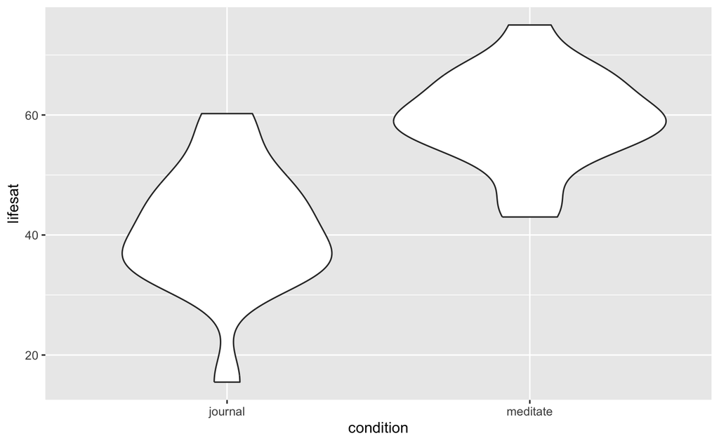

```r
lifesat_dat_7 <- lifesat_dat |>
  filter(day == 7) |>
  select(-day)

lifesat_dat_7 |>
  ggplot(aes(x = condition, y = lifesat)) +
  geom_violin()
```

what categ vars in dataset?

| condition | ppt_id | lifesat |
| --- | --- | --- |
| journal | j1 | 34.23056 |
| journal | j2 | 42.50718 |
| journal | j3 | 45.62012 |
| journal | j4 | 44.62251 |
| journal | j5 | 35.70989 |
| journal | j6 | 50.21717 |
| journal | j7 | 31.86510 |
| journal | j8 | 40.67691 |
| journal | j9 | 57.19300 |
| journal | j10 | 37.00868 |

[output cut: 26 more lines]

- condition
- ppt_id

what categ vars not an outcome or a predictor?

- ppt_id

what levels?

```r
lifesat_dat_7$ppt_id
```

```
 [1] "j1"  "j2"  "j3"  "j4"  "j5"  "j6"  "j7"  "j8"  "j9"  "j10" "j11" "j12" "j13" "j14" "j15" "j16" "j17" "j18" "m1"
[20] "m2"  "m3"  "m4"  "m5"  "m6"  "m7"  "m8"  "m9"  "m10" "m11" "m12" "m13" "m14" "m15" "m16" "m17" "m18"
```

is each level associated with more than one data point?

| ppt_id | n |
| --- | --- |
| j1 | 1 |
| j10 | 1 |
| j11 | 1 |
| j12 | 1 |
| j13 | 1 |
| j14 | 1 |
| j15 | 1 |
| j16 | 1 |
| j17 | 1 |
| j18 | 1 |

[output cut: 26 more lines]

nope, appears only 1x.

### attentiveness ~ hour + (1 + hour | child)

children’s attentiveness at school across the day

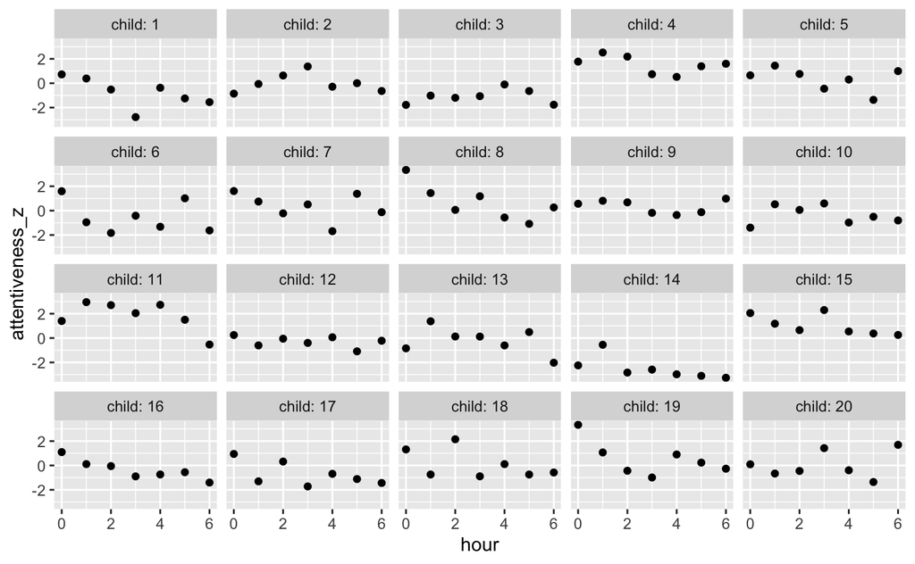

```r
attent <- sim_int_1grp_1pred(seed=1, b0 = 2, b1=-.2, N = 140) |>
  rename(
    hour = x1,
    child = g,
    attentiveness = y
  ) |>
  select(-y_bin) |>
  mutate(
    hour = hour - 1,
    child = factor(child),
    attentiveness_z = attentiveness - mean(attentiveness)
  )

attent |>
  ggplot(aes(x = hour, y = attentiveness_z)) +
  geom_point() +
  facet_wrap(~ child, labeller = label_both)
```

What categorical variables does your data contain?

- child

How many times does each each level of this variable appear in the data?

```r
attent |>
  group_by(child) |>
  count()
```

[output not shown]

each child contributes seven data points to the data set. so the data has a grouping by child.

### correct ~ trial_type + (1 + trial_type | ppt) + (1 | item)

How does people’s accuracy on an experimental task differ between conditions, and how is this difference affected by people’s DASS scores?

```r
dass <- read_csv('../data/dass.csv')
dass |> head(20)
```

| ppt_id | target_id | condition | DASS | correct |
| --- | --- | --- | --- | --- |
| XNQKPBGI | qzfri | Cond1 | 3 | 1 |
| XNQKPBGI | qzfri | Cond1 | 3 | 1 |
| XNQKPBGI | falyk | Cond1 | 3 | 1 |
| XNQKPBGI | falyk | Cond1 | 3 | 1 |
| XNQKPBGI | najdy | Cond1 | 3 | 1 |
| XNQKPBGI | najdy | Cond1 | 3 | 0 |
| XNQKPBGI | sidig | Cond1 | 3 | 1 |
| XNQKPBGI | sidig | Cond1 | 3 | 1 |
| XNQKPBGI | sgojz | Cond2 | 20 | 0 |
| XNQKPBGI | sgojz | Cond2 | 20 | 1 |

[output cut: 10 more lines]

what categ vars in dataset?

- ppt_id
- target_id
- condition
- correct

what categ vars not an outcome or a predictor?

- ppt_id
- target_id

for each categ var, what levels does it have?

```r
dass$ppt_id |> unique()
```

```
 [1] "XNQKPBGI" "KPMMAVNA" "SHCOUAIE" "CJWXRTIR" "GBESAVNE" "LZIUBUQJ" "SKSXXDXB" "VVDCTFXE" "UKXULDFI" "ZZHGPRTE"
[11] "SVDWZDUA" "XMTDTPXY" "FQIJHRTW" "BDSWPYCD" "XBWEQPGS" "ATWZYAWU" "TCCIMNWY" "KQIXNWZS" "CWMTDOUR" "MWZVAUBO"
[21] "PUVTTAOJ" "PXIKKWPW" "EEILKHBJ" "BHSLZGZR" "OTCQBTEP" "LJYAJIEL" "EADVKYSF" "OHYBKPYU" "VAOKQYRR" "EPEQXYDI"
[31] "PTGVNISG" "QOLZAMGV" "VAINLQAD" "KLBUHRTM" "PNYPKKWF" "NDQBGSZZ" "UTJPTAOI" "TMKBYGES" "ARRMOYXA" "PUZHRNTQ"
[41] "XKMJDKJN" "VZSZEALO" "MLUOERCA" "TRHSMFKN" "LEGQTVSJ" "EAGMLFKO" "IGZOLAUN" "RNBSKDOB" "JANBROQP" "TBNSJAYU"
```

```r
dass$target_id |> unique()
```

```
 [1] "qzfri" "falyk" "najdy" "sidig" "sgojz" "gxpmu" "ggrlx" "komrn" "ynsfq" "ikrys" "gyqcp" "bjvnu"
```

is each of those levels associated with more than one data point?

| ppt_id | n |
| --- | --- |
| ARRMOYXA | 24 |
| ATWZYAWU | 24 |
| BDSWPYCD | 24 |
| BHSLZGZR | 24 |
| CJWXRTIR | 24 |
| CWMTDOUR | 24 |
| EADVKYSF | 24 |
| EAGMLFKO | 24 |
| EEILKHBJ | 24 |
| EPEQXYDI | 24 |

[output cut: 40 more lines]

yes

| target_id | n |
| --- | --- |
| bjvnu | 100 |
| falyk | 100 |
| ggrlx | 100 |
| gxpmu | 100 |
| gyqcp | 100 |
| ikrys | 100 |
| komrn | 100 |
| najdy | 100 |
| qzfri | 100 |
| sgojz | 100 |

[output cut: 2 more lines]

yes.